# Ex. in Chapter 1 in Hoff (2009). A first course in Bayesian statistical methods. Springer

# Bayesian inference on a proportion

Suppose we are interested in the prevalence of an infectious disease $\theta$ in a small city. The higher the prevalence, the more public health precautions we would recommend to be put into place.

Sample: 20 individuals checked for infection **BEFORE** the sample is obtained, the number of infected individuals $Y$ is **UNKNOWN**. If $\theta$ were known, a reasonable sampling model for $Y$ is

$$Y \mid \theta \sim Bin \left(20,\theta\right).$$

## Likelihood

What is the “true” distribution for $Y$? It depends on the “true” value of $\theta$!

Let: $Y$ be the *number of infected individuals in the sample*.

```r
# Set current directory
setwd("/Users/xueyuanhuang/Desktop/R-bayesain/")
# Define variables
n <- 20
x <- 0:n
del <- 0.25

# Plot - distribution on Y as \theta varies
plot(range(x-del), c(0,.4), xlab = "number infected in the sample", ylab = "probability", type = "n")
points(x - del, dbinom(x, n, .05), type="h", col=gray(.75), lwd=3)
```

```r
points(x, dbinom(x, n, .10), type="h", col=gray(.5), lwd=3)
points(x + del, dbinom(x, n, .20), type="h", col='blue', lwd=3)
```

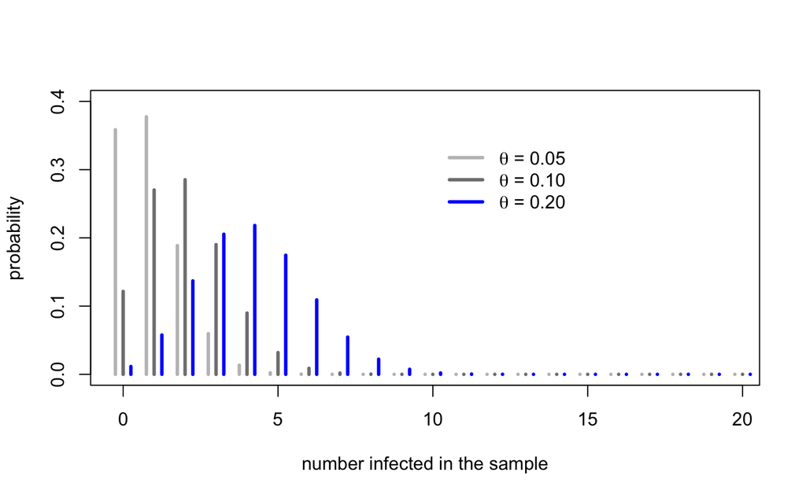

```r
# Add legend
legend(10,.35,
       legend=c(expression(paste(theta," = 0.05", sep="")),
                expression(paste(theta," = 0.10", sep="")),
                expression(paste(theta," = 0.20", sep="")) ),
       lwd=c(3,3,3),
       col=c(gray(c(.75,.5)),'blue'), bty="n")
```

Under these assumptions, what is the probability that there is no infected individual in the sample? It depends on $\theta$!

If $\theta = 5\%$, the probability that there is no infected individual in the sample is:

```r
# P(Bin(20, 0.05) = 0)
dbinom(0, 20, 0.05)
```

```
[1] 0.3584859
```

If $\theta = 10\%$, the probability is:

```r
# P(Bin(20, 0.1) = 0)
dbinom(0, 20, 0.1)
```

```
[1] 0.1215767
```

Finally, if $\theta = 20\%$, the probability is:

```r
# P(Bin(20, 0.2) = 0)
dbinom(0, 20, 0.2)
```

```
[1] 0.01152922
```

## Prior distribution

Other studies from various parts of the country indicate that the infection rate in comparable cities ranges from about $0.05$ to $0.2$ with an average prevalence of $0.1$.

We have to find a prior distribution on $\theta$ consistent with this information.

> A prior $\pi\left(\theta\right)$ that assigns a substantial amount of prob to $\left(0.05,0.2\right)$ and with expected value close to $0.1$.

There are infinite priors consistent with these 2 conditions! But for some reasons (wait a couple of classes!) we consider Beta distributions. Then, a priori:

$$\theta \sim Beta(a,b)$$

Let us check our prior in case $a = 2$ and $b = 20$

```r
# Set Beta prior parameters
a <- 2 ; b <- 20

# Prior Mean
cat(sprintf("Prior Mean: %f\n", a / (a+b)))
```

```
Prior Mean: 0.090909
```

```r
# Prior mode, if a, b > 1
cat(sprintf("Prior Mode: %f\n", (a-1) / (a-1 + b-1)))
```

```
Prior Mode: 0.050000
```

```r
# P(0.05 < \theta < 0.2)
cat(sprintf("P(0.05 < theta < 0.2): %f\n", pbeta(.20, a, b) - pbeta(.05, a, b)))
```

```
P(0.05 < theta < 0.2): 0.659326
```

```r
# P(\theta <= 0.10)
cat(sprintf("P(theta < 0.1): %f\n", pbeta(.10,a,b)))
```

```
P(theta < 0.1): 0.635270
```

```r
# Plot - Comparison between Beta distributions
p=seq(0,1,length=500)
plot(p, dbeta(p,0.5,0.5), xlab = "", ylab = "", type = "l", lwd=2, ylim=c(0,8),
     main="Comparison among beta densities")
lines(p,dbeta(p,2,3),ylim=c(0,8),col="red", lwd=2)
```

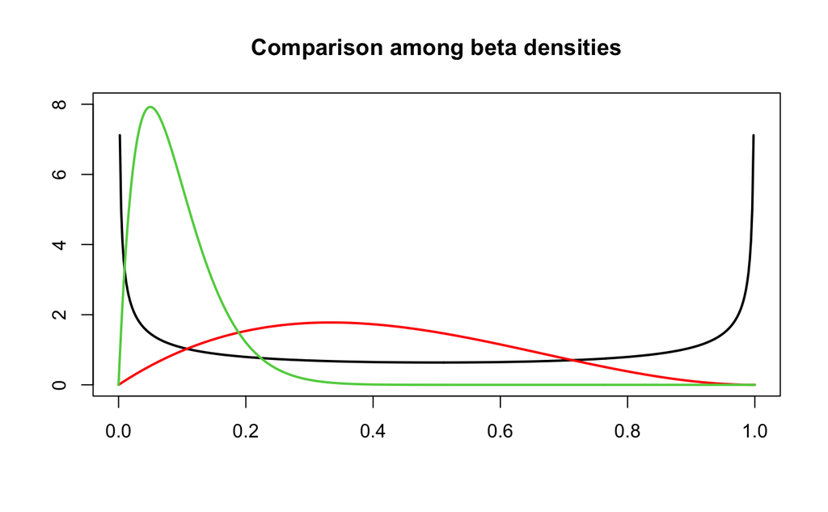

```r
lines(p,dbeta(p, a,b), ylim=c(0,8),col=3,lwd=2)
```

We then show the prior distribution chosen in this example

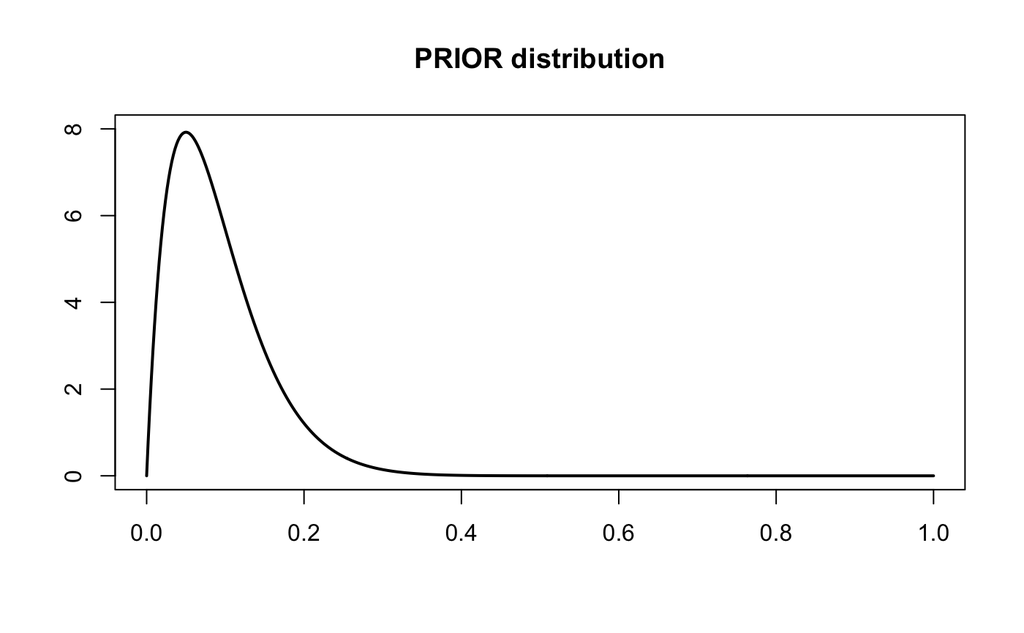

```r
# Plot - Prior chosen in this example
p=seq(0,1,length=500)
plot(p, dbeta(p,a,b), xlab = "", ylab = "", type="l", ylim=c(0,8),
     main="PRIOR distribution", lwd = 2)
```

## Observed data

Now, suppose that there are no infected individual in the observed sample. In this case the frequentist estimate of $\theta$ given by the empirical proportion is $0$. This value is totally useless, thus requiring ad-hoc procedure like adjusted Wald intervals.

```r
# Set observed data to 0 and sample size to 20
y<-0; n<-20
```

## Posterior distribution

A posteriori, we have:

$$\theta \mid y\sim Beta\left(a + y, b + n - y\right).$$

The posterior density represents our **uncertainty** on the proportion of infected individuals in the small town considered, given observation $y = 0$ (no infected individuals over 20 selected in this small town)

Let us compute relevant quantities of the posterior distribution

```r
# Set prior parameters
a <- 2 ; b <- 20

# Posterior mean
cat(sprintf("Posterior Mean: %f\n", (a+y) / (a+b+n)))
```

```
Posterior Mean: 0.047619
```

```r
# Posterior mode
cat(sprintf("Posterior Mode: %f\n", (a+y-1)/(a-1+b+n-1)))
```

```
Posterior Mode: 0.025000
```

```r
# P(0.05 < theta < 0.2 | y)
cat(sprintf("P(0.05 < theta < 0.2 | y): %f\n", pbeta(.20, a+y, b+n-y) - pbeta(.05, a+y, b+n-y)))
```

```
P(0.05 < theta < 0.2 | y): 0.384340
```

```r
# P(theta < 0.1 | y)
cat(sprintf("P(theta < 0.1 | y): %f\n", pbeta(.10, a+y, b+n-y)))
```

```
P(theta < 0.1 | y): 0.926096
```

We now plot the prior and posterior distribution:

```r
# Plot - prior and posterior distribution
theta<-seq(0,1,length=500)
plot(theta, dbeta(theta,a+y,b+n-y), type="l",
     xlab="percentage infected in the population",
     ylab="", lwd=2, ylim=c(0,16), xlim=c(0,0.5))
lines(theta, dbeta(theta,a,b),col="gray",lwd=2)
```

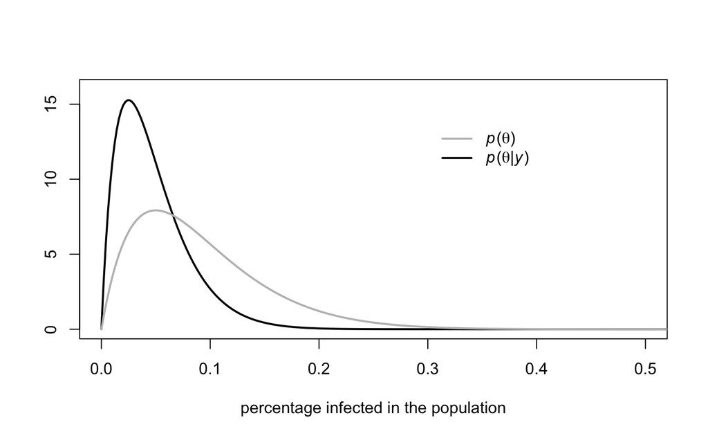

```r
# Add legend
legend(.3,14, legend=c(expression(paste(italic("p"),"(",theta,")",sep="")),
                       expression(paste(italic("p"),"(",theta,"|",italic("y"),")",sep=""))),
       bty="n", lwd=c(2,2),col=c("gray","black"))
```

This is a first example of **Bayesian Learning**. Let us see how we updated our prior belief il light of the observed data:

```r
# Prior and Posterior mean:
cat(sprintf("Prior Mean: %f\n", a / (a+b)))
```

```
Prior Mean: 0.090909
```

```r
cat(sprintf("Posterior Mean: %f\n", (a+y) / (a+b+n)))
```

```
Posterior Mean: 0.047619
```

```r
# Prior and posterior mode
cat(sprintf("Prior Mode: %f\n", (a-1) / (a-1+b-1)))
```

```
Prior Mode: 0.050000
```

```r
cat(sprintf("Posterior Mode: %f\n", (a+y-1)/(a-1+b+n-1)))
```

```
Posterior Mode: 0.025000
```

```r
# Prior and posterior P(0.05 < theta < 0.2)
cat(sprintf("P(0.05 < theta < 0.2): %f\n", pbeta(.20, a, b) - pbeta(.05, a, b)))
```

```
P(0.05 < theta < 0.2): 0.659326
```

```r
cat(sprintf("P(0.05 < theta < 0.2 | y): %f\n", pbeta(.20, a+y, b+n-y) - pbeta(.05, a+y, b+n-y)))
```

```
P(0.05 < theta < 0.2 | y): 0.384340
```

```r
# Prior and posterior P(theta < 0.1)
cat(sprintf("P(theta < 0.1): %f\n", pbeta(.10,a,b)))
```

```
P(theta < 0.1): 0.635270
```

```r
cat(sprintf("P(theta < 0.1 | y): %f\n", pbeta(.10, a+y, b+n-y)))
```

```
P(theta < 0.1 | y): 0.926096
```

Note that, a posteriori:

$$\mathbb{E}\left(\theta \mid y\right) = \frac{(a+y)}{(a+b+n)} =
\frac{n}{(a+b+n)}\cdot\frac{y}{n} + \frac{a+b}{a+b+n}\cdot\frac{a}{a+b}$$
## Classical inference

Point estimate of $\theta$ is $\frac{y}{n}$, though $y=0$, so that the point estimate of $\theta$ equals $0$: the estimate makes no sense!

a possible solution is to rely on Adjusted Wald Interval

$$\hat{\theta}_{wald} = \frac{n}{n+4}\cdot\frac{y}{n} +
\frac{4}{n+4}\cdot\frac{1}{2}$$

```r
# Compute adjusted Wald interval
cat(sprintf("Adj. Wald Estimate: %f\n", n/(n+4)*(y/n) + 4/(n+4)*(1/2)))
```

```
Adj. Wald Estimate: 0.083333
```

```r
# Compute Posterior mean in case of Beta(2,2) prior
a <- 2; b <- 2
cat(sprintf("Post. Mean w. Beta(2,2): %f\n", (y+a)/(n+a+b)))
```

```
Post. Mean w. Beta(2,2): 0.083333
```

The adjusted wald estimate corresponds to the posterior mean of $\theta$ when the prior is Beta(2,2)!!

Finally, we provide the interval estimate given the adjusted wald interval

```r
th <- n/(n+4)*(y/n) + 4/(n+4)*(1/2)
th + c(-1,1)*1.96*sqrt(th*(1-th)/n) #  interval estimates
```

```
[1] -0.03779791  0.20446458
```